# Raport PD3

Sebastian Trojan

# Wstęp

Celem eksperymetu było sprawdzenie jaki typ wykresu sprawdzi się najlepiej do porównywania dwóch obiektów, które mają kilka atrybutów. Zaproponowanymi przezeminie wykresami są: wykres słupkowy, wykres słupkowy 3D oraz spider chart. Ankietowani mieli kolejo odczytać dokładne wartości z wykresu, porównać wartości dotyczące tego samego atrybutu ale różnych obiektów, oraz porównać wartości dotyczące tego samego obiektu ale różnych atrybutów. Ankietę wypełniło 17 respondentów.

Link do ankiety: https://docs.google.com/forms/d/e/1FAIpQLSfGcZIlbfXN47A-5ArbwC-AuntFQ81Md284P4oXE7agZG0eAQ/viewform?usp=sf_link

# Wykresy

## Wykres 1:

[figure not shown]

## Wykres 2:

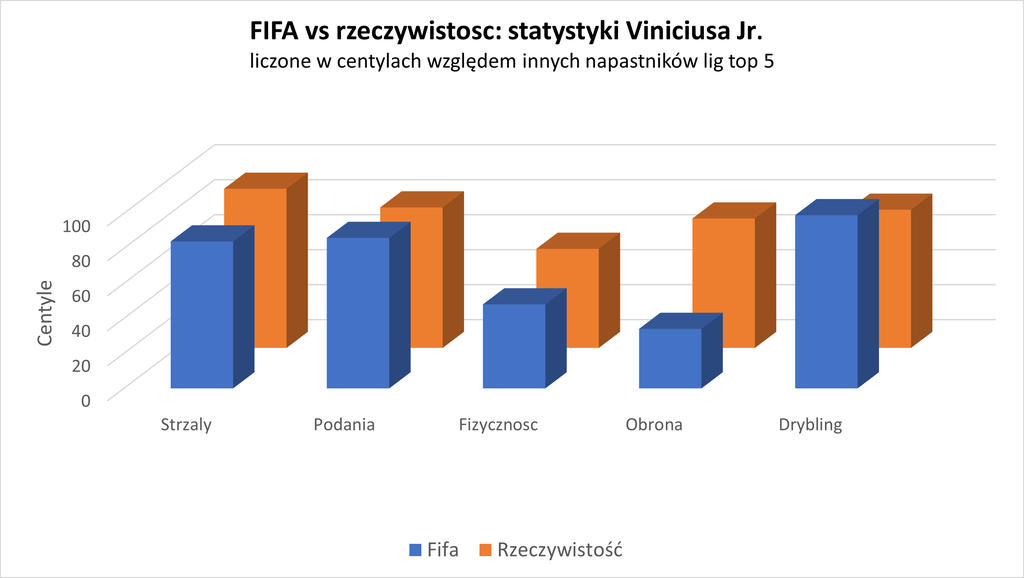

## Wykres 3:

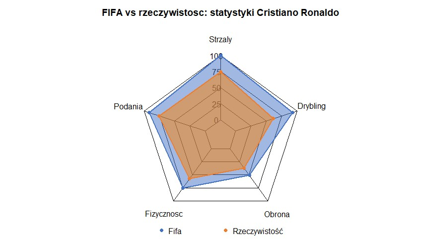

# Pytania 1, 4, 7:

1. Jaka jest statystyka podań Rodrygo w rzeczywistości?
2. Jaka jest statystyka strzałów Viniciusa w rzeczywistości?
3. Jaka jest statystyka fizyczności Ronaldo w rzeczywistości?

# Błąd w zczytywaniu dokładnych wartości z wykresów:

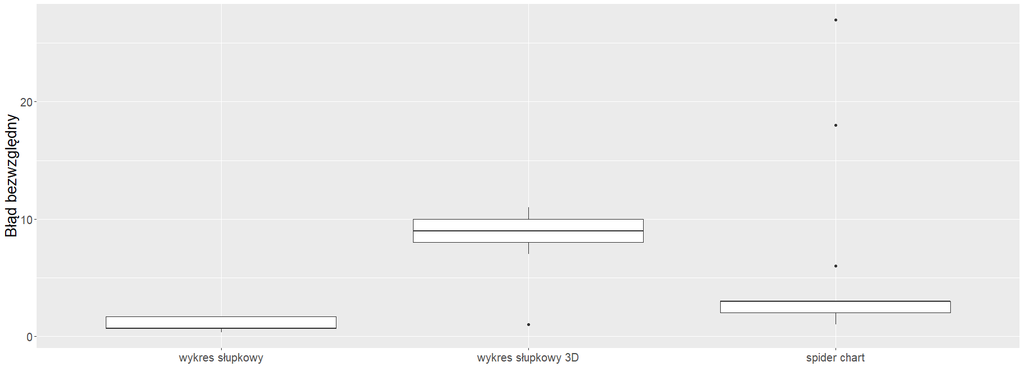

Zdecydowanie najlepiej, przy odczytywaniu dokładnej wartości z wykresu, sprawdza się klasyczny wykres słupkowy, wyniki respondentów są bardzo podobne, a mediana błedu jest bliska zera, radar chart wypada nieco gorzej pod względem wielkości błedów oraz w jego przypadku pojawia się kilka znacznych błedów w odczytywaniu wartości, natomiast wtykres 3D daje bardzo duże błędy i tylko jeden ankietowany był blisko prawdziwej wartości.

# Pytania 2, 5, 8:

2. Ile razy większa jest statystyka fizyczności Rodrygo w rzeczywistości niż w fifie?
3. Ile razy większa jest statystyka obrony Viniciusa w rzeczywistości niż w fifie?
4. Ile razy większa jest statystyka dryblingu Ronaldo w fifie niż w rzeczywistości?

# Błąd w porównywaniu tego samego atrybutu dla dwóch różnych obiektów:

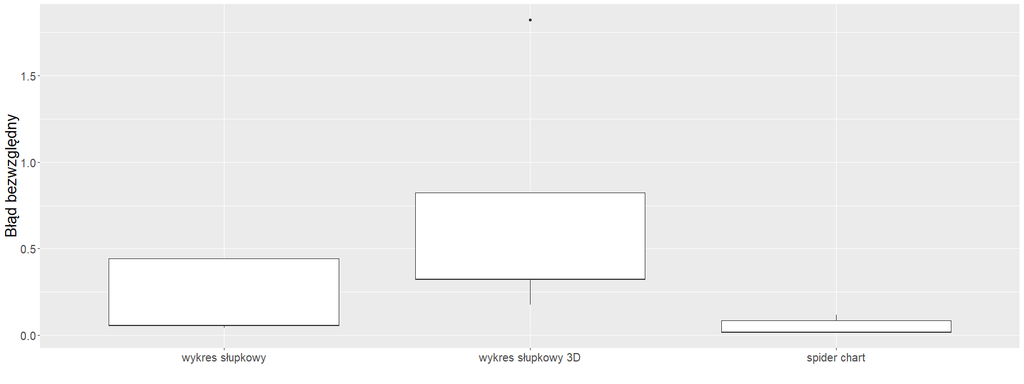

Podczas porównywania tego samego atrybutu dla różnych obiektów najlepiej wypada spider chart, mediana błędów dla wykresu słupkowego także jest niska, ale tutaj zdażyło się więcej odpowiedzi odbiegających od odpowiedzi poprawnej, natomiast wyniki odczytywane z wykresu 3D są zdecydowanie bardziej błędne.

# Pytania 3, 6, 9:

3. Ile razy większa jest statystyka podań Rodrygo w fifie od jego statystyki fizyczności w fifie?
4. Ile razy większa jest statystyka dryblingu Viniciusa w fifie od jego statystyki obrony w fifie?
5. Ile razy większa jest statystyka podań Ronaldo w rzeczywistości od jego statystyki obrony w rzeczywistości?

# Błąd w porównywaniu różnych atrybutów dla tego samego obiektu:

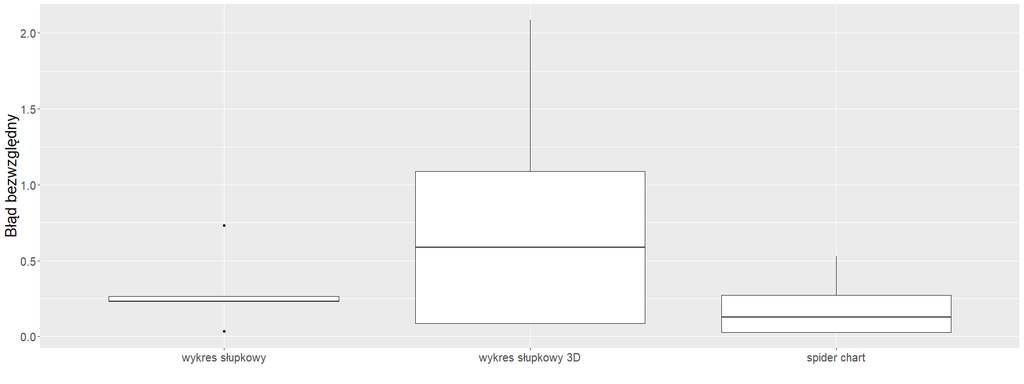

Podczas porównywania różnych atrybutów dla tego samego obiektu teoretycznie, najlepiej wypada spider chart ale występuje w nim większy rozstrzał odpowiedzi, niż w wykresie słupkowym. Dodatkowo lepsza dokładność jw jego odpowiedziach może wynikać z tego, że odpowiedź dla pytania 3. to około 5.7 a dla pytania 9. to około 2, zatem łatwiej było dać odpowiedź bliską poprawnej w pytaniu nr 9. Co moim zdaniem mogło wpłynąć na wyniki i było błędem podczas tworzenia ankiety. Wykres 3D klasycznie wypadł zdecywowanie najgorzej.

# Pytania 10, 11:

10. Z którego wykresu najłatwiej jest Ci odczytywać dane?
11. Z którego wykresu najtrudniej jest Ci odczytywać dane?

# Odczucia ankietowanych przy zczytywaniu dokładnych wartości z wykresów:

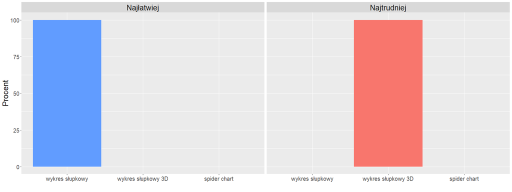

Ewidentnie ankietowani najbardziej lubią odczytywać dane z wykresu słupkowego, a najmniej z wykresu słupkowego 3D, co pokrywa się z wcześniejszymi wynikami.

# Pytania 12, 13:

12. Na którym wykresie najłatwiej porównuje Ci się dane tej samej statystyki?
13. Na którym wykresie najtrudniej porównuje Ci się dane tej samej statystyki?

# Odczucia ankietowanych przy porównywaniu tego samego atrybutu dla dwóch różnych obiektów:

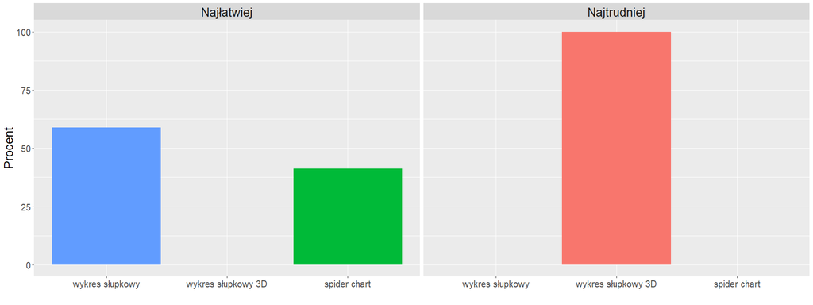

W wyborze najwygodnojszego wykrseu, do porównywania tego samego atrybutu dla dwóch różnych obiektów, ankietowani są podzieleni, jednak tutaj także wykres słupkowy przeważa nad spider chartem. Natomiat nagorzej, jak zwykle, wypadł wykres 3D.

# Pytania 14, 15:

14. Na którym wykresie najłatwiej porównuje Ci się dane tej samej kategorii (tego samego koloru)?
15. Na którym wykresie najtrudniej porównuje Ci się dane tej samej kategorii (tego samego koloru)?

# Odczucia ankietowanych przy porównywaniu różnych atrybutów dla tego samego obiektu:

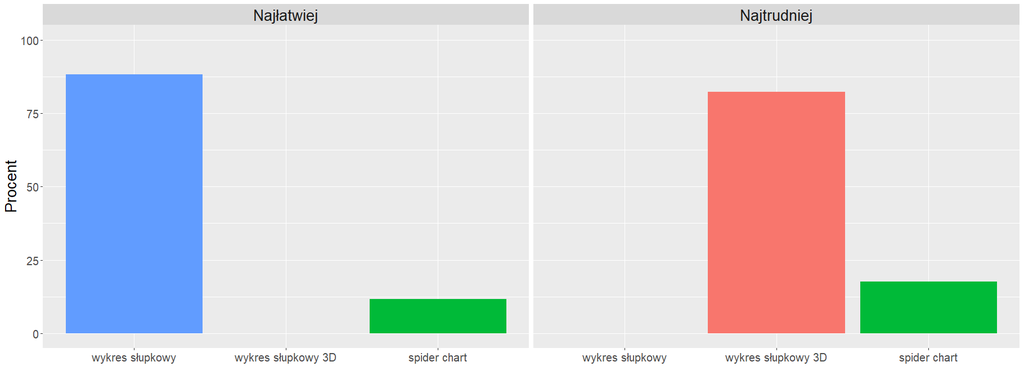

Ankietowani zdecydowanie woleli porównywać różne atrybuty dla tego samego obiektu na wykresie słupkowym, niż na spider charcie. Ponadto kilku ankietowanych wolało nawet wykres 3D od wykresu spider chart.

# Wnikoski

Z ankiety wynika że najlepsze wyniki i największą wygodę dają ankietowanym klasyczne wykresy słupkowe. Jednak jeżeli nie zależy nam bardzo zczytywaniu z wykresów dokładnych danych i chcemy porówywać przedewszyskim poszczególne atrybuty, dla dwóch różnych obiektów, to warto się zastanowić nad zastosowaniem spider chartu. Natomiast wykres 3D mimo, że w kategoriach porównywania atrybutów wypadł nieco lepiej niż w zczytywaniu danych z wykresu, to wciąż jest beznadziejny i bezużyteczny.